# Chapter 9: Tree-Based Methods

Yang Li

2024-03-20

# Decision Tree

- Decision trees are a non-parametric supervised learning method used for classification and regression.

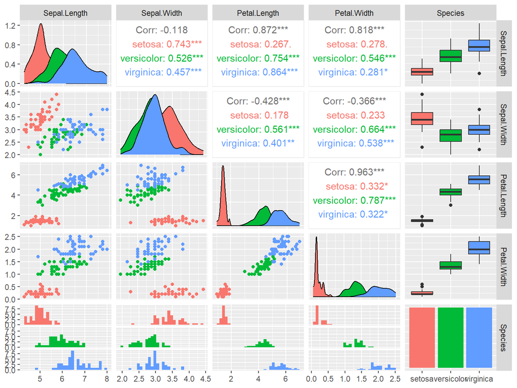

  ```r
  library(GGally)
  ggpairs(iris, aes(color=Species))
  ```

- After observing the density functions on the diagonal, we may come up with the following simple rule to separate them.

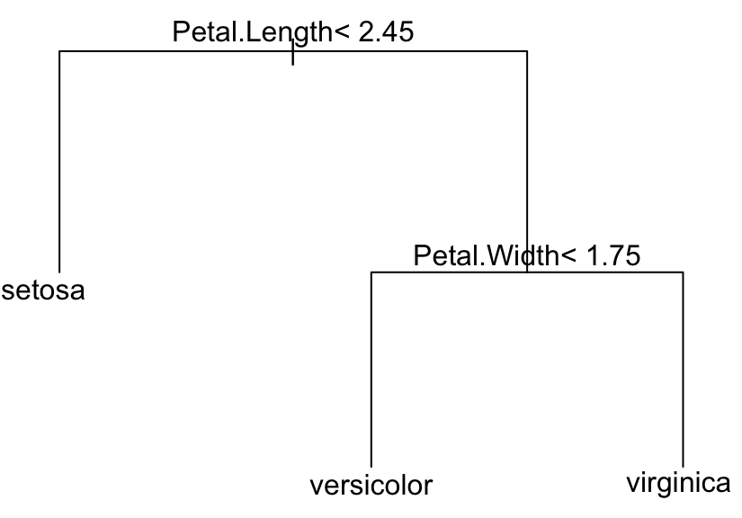

- This is a decision tree.
- We can also visualize it as the following three-region partition.

[figure not shown]

# Decision Tree

- Some notations

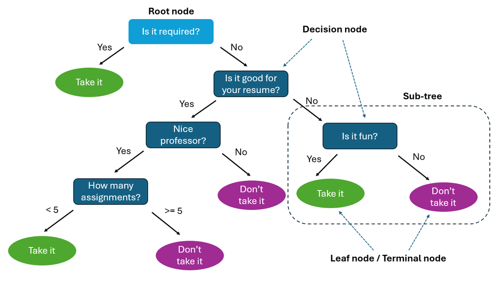

# Decision Tree

- The algorithm of decision tree models works by repeatedly partitioning the data into multiple sub-spaces, so that the outcomes in each final sub-space is as homogeneous as possible.
- This procedure is called **recursive partitioning**.
- Tree model works for both *regression* and *classification* problems.
  - Regression tree: continuous response variable
  - Classification tree: categorial response variable
- The decision rules generated by model are generally visualized as a binary tree.

# Regression Tree with **tree**

- Let’s use the *Boston* data set from earlier chapters. First, let’s use the *tree* function in the *tree* package.

  ```r
  library(ISLR2)
  library(tree)
  set.seed(123)
  train <- sample(1:nrow(Boston), round(nrow(Boston)*0.8))
  train.boston <- Boston[train, ]
  test.boston <- Boston[-train, ]
  tree.boston <- tree(medv ~ ., Boston, subset=train)
  # this is the same as
  # tree(medv ~ ., train.boston)
  tree.boston
  ```

  ```
  ## node), split, n, deviance, yval
  ##       * denotes terminal node
  ##
  ##  1) root 405 34110.0 22.51
  ##    2) rm < 6.941 349 14110.0 20.03
  ##      4) lstat < 14.805 220  5485.0 23.27
  ##        8) dis < 1.4618 5  1061.0 38.58 *
  ##        9) dis > 1.4618 215  3224.0 22.91
  ##         18) rm < 6.542 167  1453.0 21.63 *
  ##         19) rm > 6.542 48   537.2 27.38 *
  ##      5) lstat > 14.805 129  2365.0 14.49
  ##       10) crim < 7.46495 73   826.6 16.87 *
  ##       11) crim > 7.46495 56   589.9 11.40 *
  ##    3) rm > 6.941 56  4462.0 37.97
  ##      6) rm < 7.437 34  1529.0 32.59
  ##       12) lstat < 8.355 29   653.8 34.07 *
  ##       13) lstat > 8.355 5   446.6 24.04 *
  ##      7) rm > 7.437 22   433.1 46.27 *
  ```

- The tree can be visualized as well.

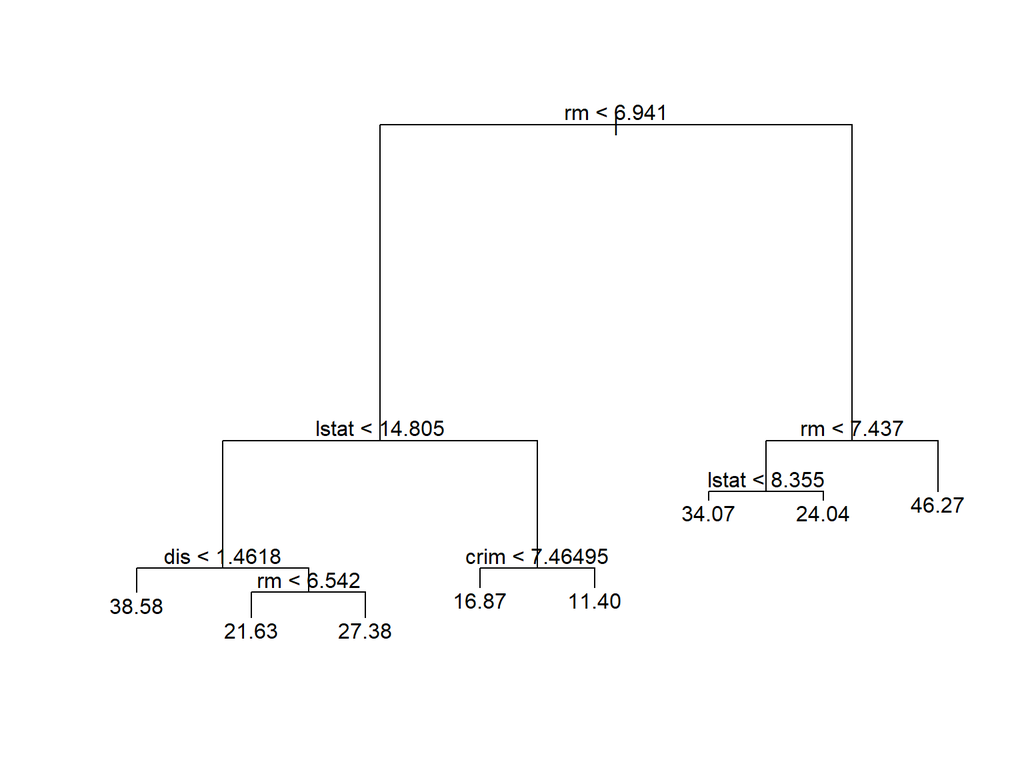

  ```r
  plot(tree.boston)
  text(tree.boston, pretty=0)
  ```

- Prediction on new observations can also be done easily.

  ```r
  pred.boston <- predict(tree.boston, test.boston)
  head(pred.boston)
  ```

  ```
  ##        1       15       17       19       28       37
  ## 27.38125 21.62934 21.62934 21.62934 16.86712 21.62934
  ```

- All observations falling into the same terminal node have the same predicted value.

# Regression Tree with **rpart**

- Building the regression tree can also be done by the *rpart* function in the package of the same name.

  ```r
  library(rpart)
  tree.boston.rpart <- rpart(medv ~ ., train.boston)
  summary(tree.boston.rpart)
  ```

  ```
  ## Call:
  ## rpart(formula = medv ~ ., data = train.boston)
  ##   n= 405
  ##
  ##           CP nsplit rel error    xerror       xstd
  ## 1 0.45543367      0 1.0000000 1.0068871 0.09451034
  ## 2 0.18365489      1 0.5445663 0.6865288 0.06415801
  ## 3 0.07326413      2 0.3609114 0.4029651 0.04837212
  ## 4 0.03494703      3 0.2876473 0.3326698 0.04380328
  ## 5 0.02780354      4 0.2527003 0.2833983 0.04229107
  ## 6 0.02747351      5 0.2248967 0.2733679 0.04180982
  ## 7 0.01922641      6 0.1974232 0.2670671 0.04165340
  ## 8 0.01138276      7 0.1781968 0.2296673 0.03452099
  ## 9 0.01000000      8 0.1668141 0.2288945 0.03455975
  ##
  ## Variable importance
  ##      rm   lstat    crim     nox     age     tax ptratio     dis   indus      zn
  ##      30      22       7       7       7       6       6       6       3       3
  ##     rad
  ##       2
  ##
  ## Node number 1: 405 observations,    complexity param=0.4554337
  ##   mean=22.50617, MSE=84.22695
  ##   left son=2 (349 obs) right son=3 (56 obs)
  ##   Primary splits:
  ##       rm      < 6.941    to the left,  improve=0.4554337, (0 missing)
  ##       lstat   < 9.645    to the right, improve=0.4425173, (0 missing)
  ##       ptratio < 19.9     to the right, improve=0.2640979, (0 missing)
  ##       indus   < 7.225    to the right, improve=0.2507729, (0 missing)
  ##       nox     < 0.6695   to the right, improve=0.2172595, (0 missing)
  ##   Surrogate splits:
  ##       lstat   < 4.15     to the right, agree=0.909, adj=0.339, (0 split)
  ##       ptratio < 14.55    to the right, agree=0.889, adj=0.196, (0 split)
  ##       zn      < 87.5     to the left,  agree=0.872, adj=0.071, (0 split)
  ##       indus   < 1.605    to the right, agree=0.872, adj=0.071, (0 split)
  ##
  ## Node number 2: 349 observations,    complexity param=0.1836549
  ##   mean=20.02521, MSE=40.44297
  ##   left son=4 (129 obs) right son=5 (220 obs)
  ##   Primary splits:
  ```

  [output cut: 119 more lines]

  ```
  ##   Surrogate splits:
  ##       lstat   < 5.495    to the right, agree=0.684, adj=0.26, (0 split)
  ##       zn      < 31.5     to the left,  agree=0.675, adj=0.24, (0 split)
  ##       rad     < 6.5      to the left,  agree=0.632, adj=0.14, (0 split)
  ##       ptratio < 17.7     to the right, agree=0.624, adj=0.12, (0 split)
  ##       indus   < 3.095    to the right, agree=0.615, adj=0.10, (0 split)
  ##
  ## Node number 23: 7 observations
  ##   mean=36.55714, MSE=139.311
  ##
  ## Node number 44: 67 observations
  ##   mean=22.6, MSE=9.159701
  ##
  ## Node number 45: 50 observations
  ##   mean=27.386, MSE=9.920804
  ```

- Visualization shows a similar tree as the one by *tree*.

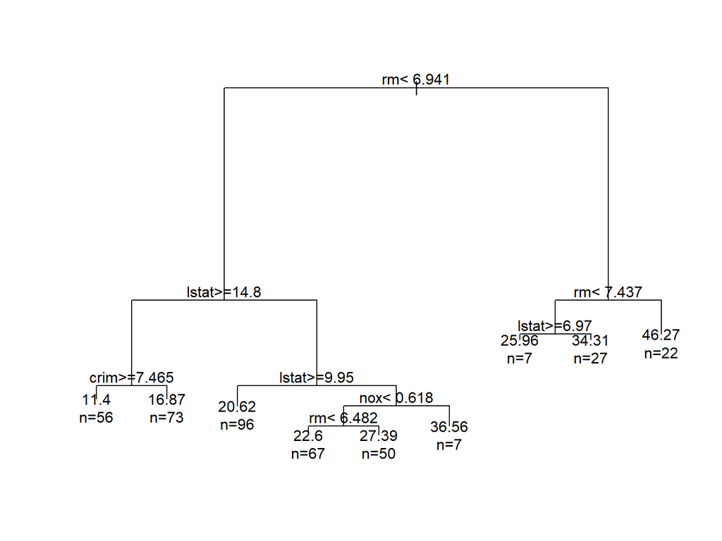

  ```r
  par(xpd=NA)
  plot(tree.boston.rpart)
  text(tree.boston.rpart, use.n=TRUE)
  ```

  ```r
  # use.n shows the number of observations at each leaf node.
  ```

# Classification Tree with **rpart**

- We can use *rpart* as a classifier.

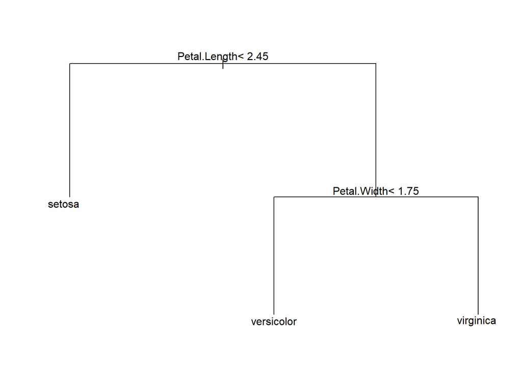

  ```r
  iris.model <- rpart(Species ~., data=iris)
  par(xpd=NA) # otherwise on some devices the text is clipped
  plot(iris.model)
  text(iris.model)
  ```

- The rules in the tree can be printed out.

  ```r
  print(iris.model, digits=2)
  ```

  ```
  ## n= 150
  ##
  ## node), split, n, loss, yval, (yprob)
  ##       * denotes terminal node
  ##
  ## 1) root 150 100 setosa (0.333 0.333 0.333)
  ##   2) Petal.Length< 2.4 50   0 setosa (1.000 0.000 0.000) *
  ##   3) Petal.Length>=2.4 100  50 versicolor (0.000 0.500 0.500)
  ##     6) Petal.Width< 1.8 54   5 versicolor (0.000 0.907 0.093) *
  ##     7) Petal.Width>=1.8 46   1 virginica (0.000 0.022 0.978) *
  ```

- Making predictions is a routine job.

  ```r
  new.iris <- data.frame(Sepal.Length=c(6.5, 4.7), Sepal.Width=c(3.0, 2.9),
                        Petal.Length=c(5.2, 1.6), Petal.Width=c(2.0, 0.3))
  predict(iris.model, new.iris, "class")
  ```

  ```
  ##         1         2
  ## virginica    setosa
  ## Levels: setosa versicolor virginica
  ```